# 01_Data processing

2026-04-04

```r
library(readxl)
library(dplyr)
library(lubridate)
library(tidyr)
library(forecast)
```

```r
library(tseries)
library(ggplot2)
```

We use three raw data series: oil price, U.S. oil stock, and U.S. domestic oil production. Oil price is the dependent variable of interest. U.S. oil stock and U.S. domestic oil production are included to account for supply-side conditions that may influence oil prices. We hypothesize that geopolitical events affect oil prices indirectly by changing U.S. oil inventories and, in turn, domestic oil production. These changes may then contribute to movements in oil prices.

## Data Input

```r
wti_raw <- read_excel("Data/Cushing, OK WTI Spot Price FOB (Dollars per Barrel).xls")
stock_raw <- read_excel("Data/U.S. Ending Stocks of Crude Oil (Thousand Barrels).xls")
prod_raw <- read_excel("Data/U.S. Field Production of Crude Oil (Thousand Barrels per Day).xls")
```

## Data Wrangling

[figure not shown]

```r
wti_df <- data.frame(
  Date  = as.Date(wti_raw[[1]], format = "%Y/%m/%d"),
  Price = as.numeric(wti_raw[[2]])
) %>%
  na.omit() %>%
  arrange(Date)

wti_ts <- ts(wti_df[,2], start = c(1986,1), frequency = 12)

wti_sub <- window(wti_ts, start = c(2005, 1), end = c(2025, 12))

# Plot WTI training series
plot(wti_sub, main = "WTI Price (2000-2025)", ylab = "Price", xlab = "Time")
```

```r
# Stationarity check
adf.test(wti_sub)
```

```
##
##  Augmented Dickey-Fuller Test
##
## data:  wti_sub
## Dickey-Fuller = -2.931, Lag order = 6, p-value = 0.1838
## alternative hypothesis: stationary
```

```r
fit_arima <- auto.arima(wti_sub)
fit_arima
```

```
## Series: wti_sub
## ARIMA(1,1,0)
##
## Coefficients:
##          ar1
##       0.3452
## s.e.  0.0591
##
## sigma^2 = 33.69:  log likelihood = -797.12
## AIC=1598.24   AICc=1598.29   BIC=1605.29
```

# Involve fundamentals (production and inventores) and shock (war dummy) to test significance

To test the explanatory power of each variable within a time-series framework, we estimated an ARIMAX model incorporating all three variables as external regressors, which accounts for the serial correlation inherent in monthly oil price data by modeling the error term as an ARIMA process. The results indicated that domestic production and crude oil ending stocks were statistically insignificant, with near-zero coefficients relative to their standard errors. Both variables were therefore excluded from further analysis—domestic production on the basis of statistical insignificance. The war dummy, by contrast, returned a statistically significant positive coefficient of approximately $14 per barrel (t ≈ 3.44), confirming that geopolitical shocks constitute a meaningful and discrete disruption to oil price dynamics that warrants further investigation.

```
## Series: wti_sub
## Regression with ARIMA(0,0,5)(1,0,1)[12] errors
##
## Coefficients:
##          ma1     ma2     ma3     ma4     ma5    sar1    sma1  intercept
##       1.3225  1.2924  1.0174  0.6782  0.2893  0.0736  0.1154   122.8726
## s.e.  0.0671  0.1005  0.1040  0.0845  0.0593  0.4727  0.4184    12.1960
##       prod_sub  stock_sub  war_dummy
##          1e-04     -1e-04    14.1171
## s.e.     8e-04      1e-04     4.1097
##
## sigma^2 = 34.52:  log likelihood = -799.6
## AIC=1623.2   AICc=1624.51   BIC=1665.56
```

# Use Gulf War to train and test for Ukraine War

we adopt a historical analogy framework using the 1990–1991 Gulf War as a structural template. The underlying identification assumption is that major geopolitical oil supply shocks generate structurally similar patterns of price disturbance, allowing the shock profile of a historical conflict to serve as a proxy for that of a more recent one.

Four baseline forecasting models (ARIMA, ETS, TBATS, and ARIMA with Fourier) were estimated on WTI prices from January 1986 to June 1990, the pre-Gulf War period. The forecasts were generated over July 1990–January 1991 (seven months), representing the expected price trajectory in the absence of conflict. The war shock vector for each model was computed as the difference between actual and forecast prices, yielding a 7-month series that captures the dynamic shape of the geopolitical price disturbance. Results are reported in the table below.

Gulf War Shock Vectors by Model (Log Scale)

| Model | Month 1 | Month 2 | Month 3 | Month 4 | Month 5 | Month 6 | Month 7 |
| --- | --- | --- | --- | --- | --- | --- | --- |
| ARIMA | 0.0997 | 0.4918 | 0.6964 | 0.7692 | 0.6606 | 0.4907 | 0.4126 |
| ETS | 0.1184 | 0.5257 | 0.7423 | 0.8247 | 0.7237 | 0.5600 | 0.4869 |
| TBATS | 0.0796 | 0.4718 | 0.6764 | 0.7492 | 0.6406 | 0.4707 | 0.3926 |
| ARIMA+Fourier | 0.1368 | 0.5020 | 0.6863 | 0.7879 | 0.6728 | 0.4267 | 0.3127 |

# Russia-Ukraine War’s effect forecast

The same four models were re-estimated on WTI prices from January 2018 to January 2022, and forecasts were generated for February–August 2022. The Gulf War shock vector was added to each model’s predicted baseline to produce a war-adjusted price forecast for the Ukraine War period. Forecast accuracy was evaluated against realized WTI prices using RMSE, MAE, and MAPE.

The results of predicted WTI prices during the Russia-Ukraine War period are listed below.

Forecast WTI Price during Russia-Ukraine War Period

| Model | Feb | Mar | Apr | May | Jun | Jul | Aug |
| --- | --- | --- | --- | --- | --- | --- | --- |
| ARIMA | 94.0441 | 124.4621 | 141.0114 | 143.2817 | 123.4339 | 101.1933 | 91.6863 |
| ETS | 93.6822 | 140.7698 | 174.8171 | 189.8330 | 171.6068 | 145.6957 | 135.4124 |
| TBATS | 99.0703 | 146.6456 | 179.9375 | 193.5227 | 173.6013 | 146.4845 | 135.4767 |
| ARIMA+Fourier | 95.7710 | 120.4252 | 132.0262 | 138.2824 | 120.1459 | 93.5012 | 83.9626 |

We then compared the predicted results with the real-world data, using the code accuracy() to find the model that gave the best value.

```
##                 ME     RMSE      MAE        MPE     MAPE
## ARIMA   -13.930417 20.75529 14.61910 -13.088186 13.81323
## ETS     -47.173848 53.09405 47.17385 -44.911690 44.91169
## TBAT    -50.448361 55.91296 50.44836 -48.093926 48.09393
## Fourier  -8.930629 17.27078 14.02386  -8.244442 13.48812
```

The ARIMA+Fourier specification achieved the lowest error across all three metrics and was selected as the final model for subsequent forecasting.

# Use Russia-Ukraine War’s shock to predict WTI price after 2026.4

To forecast the potential WTI price impact of the current Middle East conflict, a final ARIMA+Fourier baseline model was estimated on WTI prices from September 2022 to March 2026—the post-Ukraine War period. A 7-month forecast was generated from April 2026 onward, and the Ukraine War shock vector derived from the ARIMA+Fourier model was added to this baseline to produce the final war-adjusted price forecast. This assumes that the current conflict generates a price disturbance pattern analogous in structure to that observed during the Russia–Ukraine War.

Predicted WTI Crude Oil Prices (April–October 2026)

| Date | Predicted WTI Price ($/barrel) |
| --- | --- |
| Apr 2026 | 102.19 |
| May 2026 | 141.49 |
| Jun 2026 | 147.09 |
| Jul 2026 | 166.91 |
| Aug 2026 | 176.88 |
| Sep 2026 | 153.68 |
| Oct 2026 | 137.27 |

# Graph the forecast result

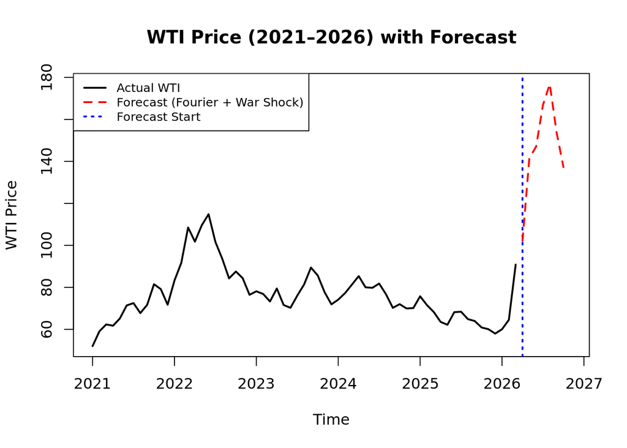